# P02CP02V2AD2

Antonio Lúcio

17 de dezembro de 2017

Este é um laboratório da disciplina de Análise de Dados 2 - UFCG - 2017.2

- Sobre a tarefa: Construir modelos preditivos de regressão para a predição de votação de candidatos à Câmara Federal de Deputados
- Sobre os dados: Foram obtidos através do TSE. Algumas das variáveis disponíveis: Nome do deputado, partido, estado, número de doaçãoes e doadores, total receita, quantidade de receitas, etc.

Lendo e fazendo um pre-processamento dos dados:

```r
train <- read.csv("train.csv", encoding="UTF-8")
test <- read.csv("test.csv", encoding="UTF-8")
submission <- read.csv("sample_submission.csv")

#Mudando os valores de NA para zero
train[is.na(train)] <- 0
test[is.na(test)] <- 0
```

1. Usando todas as variáveis disponíveis, tune (usando validação cruzada): (i) um modelo de regressão Ridge, (ii) um modelo de regressão Lasso e (iii) um modelo KNN. Para os modelos de regressão linear, o parâmetro a ser tunado é o lambda (penalização dos coeficientes) e o KNN o número de vizinhos.

```r
# K-fold cross-validation -> 10-fold CV
fitControl <- trainControl(method = "cv",
                    number = 5,
                    search= "random")

# variação do lambda
lambdaGrid <- expand.grid(lambda = 10^seq(2, -10, length=30))

# variação do fraction
fractionGrid <- expand.grid(fraction = seq(0.001, 1, length = 30))

# variação no número de vizinho
neighborsGrid <- expand.grid(k = seq(1, 30, length=30))

# retirando variáveis que não são importantes (explicação dada no lab passado)
train_dadosFiltrados <- train %>% select(-nome, -cargo, -setor_economico_receita, -setor_economico_despesa, -numero_cadidato)
test_dadosFiltrados <- test %>% select(-nome, -cargo, -setor_economico_receita, -setor_economico_despesa, -numero_cadidato)
```

```r
#Treinando os modelos

# (i) modelo de regressão Ridge
model_ridge <- train(votos ~ .,
          data = train_dadosFiltrados,
          method = "ridge",
          trControl = fitControl,
          tuneGrid = lambdaGrid,
          na.action = na.omit)

model_ridge
```

```
## Ridge Regression
##
## 4152 samples
##   20 predictor
##
## No pre-processing
## Resampling: Cross-Validated (5 fold)
## Summary of sample sizes: 3321, 3321, 3322, 3322, 3322
## Resampling results across tuning parameters:
##
##   lambda        RMSE       Rsquared   MAE
##   1.000000e-10   32581.92  0.4837223  13022.06
##   2.592944e-10   32581.91  0.4837224  13022.06
##   6.723358e-10   32581.90  0.4837228  13022.06
##   1.743329e-09   32581.87  0.4837238  13022.05
##   4.520354e-09   32581.79  0.4837264  13022.04
##   1.172102e-08   32581.58  0.4837332  13022.00
##   3.039195e-08   32581.04  0.4837506  13021.91
##   7.880463e-08   32579.66  0.4837950  13021.66
##   2.043360e-07   32576.24  0.4839056  13021.03
##   5.298317e-07   32568.24  0.4841646  13019.53
##   1.373824e-06   32552.08  0.4846899  13016.24
##   3.562248e-06   32527.74  0.4854871  13010.40
##   9.236709e-06   32504.40  0.4862574  13002.99
##   2.395027e-05   32489.53  0.4867470  12996.51
##   6.210169e-05   32479.23  0.4870688  12991.97
##   1.610262e-04   32466.39  0.4874334  12988.08
##   4.175319e-04   32443.42  0.4880589  12982.41
##   1.082637e-03   32406.30  0.4890874  12971.96
##   2.807216e-03   32370.57  0.4901758  12955.54
##   7.278954e-03   32367.25  0.4905676  12938.60
##   1.887392e-02   32406.66  0.4901319  12955.72
##   4.893901e-02   32497.41  0.4894801  13002.96
##   1.268961e-01   32704.88  0.4906452  13141.06
##   3.290345e-01   33579.77  0.4957298  13796.22
##   8.531679e-01   38053.84  0.5018385  16937.86
##   2.212216e+00   53901.56  0.5037172  27172.51
##   5.736153e+00   86119.01  0.5018822  46764.07
##   1.487352e+01  124170.94  0.4997628  69446.35
##   3.856620e+01  152391.84  0.4985496  86160.76
##   1.000000e+02  167456.11  0.4980035  95077.86
##
## RMSE was used to select the optimal model using the smallest value.
## The final value used for the model was lambda = 0.007278954.
```

```r
# (ii) modelo de regressão Lasso
model_lasso <- train(votos ~ .,
                    data = train_dadosFiltrados,
                    method = "lasso",
                    trControl = fitControl,
                    tuneGrid = fractionGrid,
                    na.action = na.omit)

model_lasso
```

```
## The lasso
##
## 4152 samples
##   20 predictor
##
## No pre-processing
## Resampling: Cross-Validated (5 fold)
## Summary of sample sizes: 3320, 3321, 3322, 3322, 3323
## Resampling results across tuning parameters:
##
##   fraction    RMSE      Rsquared   MAE
##   0.00100000  38962.44  0.4909108  19285.11
##   0.03544828  34065.41  0.4930647  15768.14
##   0.06989655  32288.79  0.4936429  13952.00
##   0.10434483  31893.51  0.5009390  12920.20
##   0.13879310  31809.25  0.5034868  12487.39
##   0.17324138  31925.87  0.5017710  12466.65
##   0.20768966  32041.33  0.5006406  12547.20
##   0.24213793  32161.42  0.4993366  12641.62
##   0.27658621  32232.76  0.4989435  12707.94
##   0.31103448  32331.48  0.4976874  12787.08
##   0.34548276  32423.42  0.4960988  12855.39
##   0.37993103  32477.15  0.4951149  12903.67
##   0.41437931  32514.23  0.4945775  12928.17
##   0.44882759  32548.27  0.4941091  12952.35
##   0.48327586  32577.26  0.4937599  12973.98
##   0.51772414  32601.94  0.4934570  12990.66
##   0.55217241  32620.86  0.4932425  13007.81
##   0.58662069  32635.54  0.4930699  13021.41
##   0.62106897  32646.20  0.4929499  13033.11
##   0.65551724  32651.29  0.4928308  13037.09
##   0.68996552  32652.55  0.4928068  13039.03
##   0.72441379  32654.11  0.4927661  13039.70
##   0.75886207  32655.30  0.4927306  13040.15
##   0.79331034  32656.50  0.4926949  13040.61
##   0.82775862  32657.71  0.4926590  13041.07
##   0.86220690  32658.92  0.4926228  13041.52
##   0.89665517  32660.15  0.4925865  13041.98
##   0.93110345  32661.38  0.4925499  13042.44
##   0.96555172  32662.62  0.4925132  13042.89
##   1.00000000  32663.86  0.4924762  13043.35
##
## RMSE was used to select the optimal model using the smallest value.
## The final value used for the model was fraction = 0.1387931.
```

```r
# (iii) modelo usando KNN         MLEHOR
model_knn <- train(votos ~ .,
                    data = train_dadosFiltrados,
                    method = "knn",
                    trControl = fitControl,
                    tuneGrid = neighborsGrid,
                    na.action = na.omit)

model_knn
```

```
## k-Nearest Neighbors
##
## 4152 samples
##   20 predictor
##
## No pre-processing
## Resampling: Cross-Validated (5 fold)
## Summary of sample sizes: 3321, 3323, 3320, 3322, 3322
## Resampling results across tuning parameters:
##
##   k   RMSE      Rsquared   MAE
##    1  42807.87  0.3679890  12289.917
##    2  35536.74  0.4354671  11001.300
##    3  32969.45  0.4915441  10209.209
##    4  32020.38  0.5105903   9994.939
```

[output cut: 29 more lines]

2. Compare os três modelos em termos do erro RMSE de validação cruzada.

Temos os seguintes resultados:

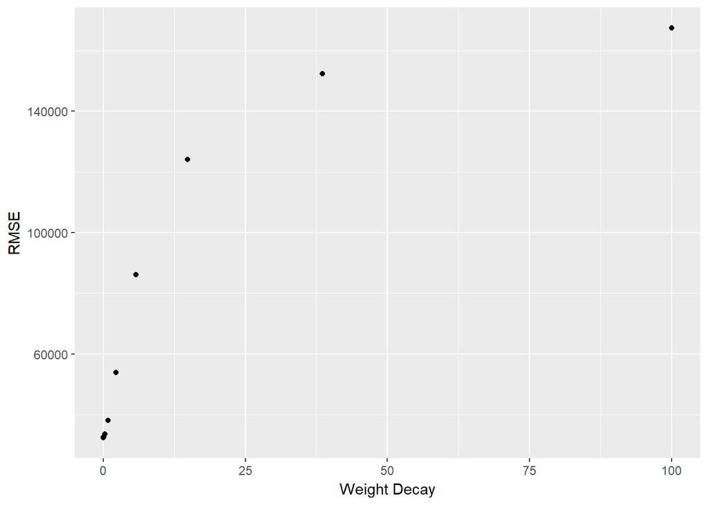

```r
ggplot(model_ridge)
```

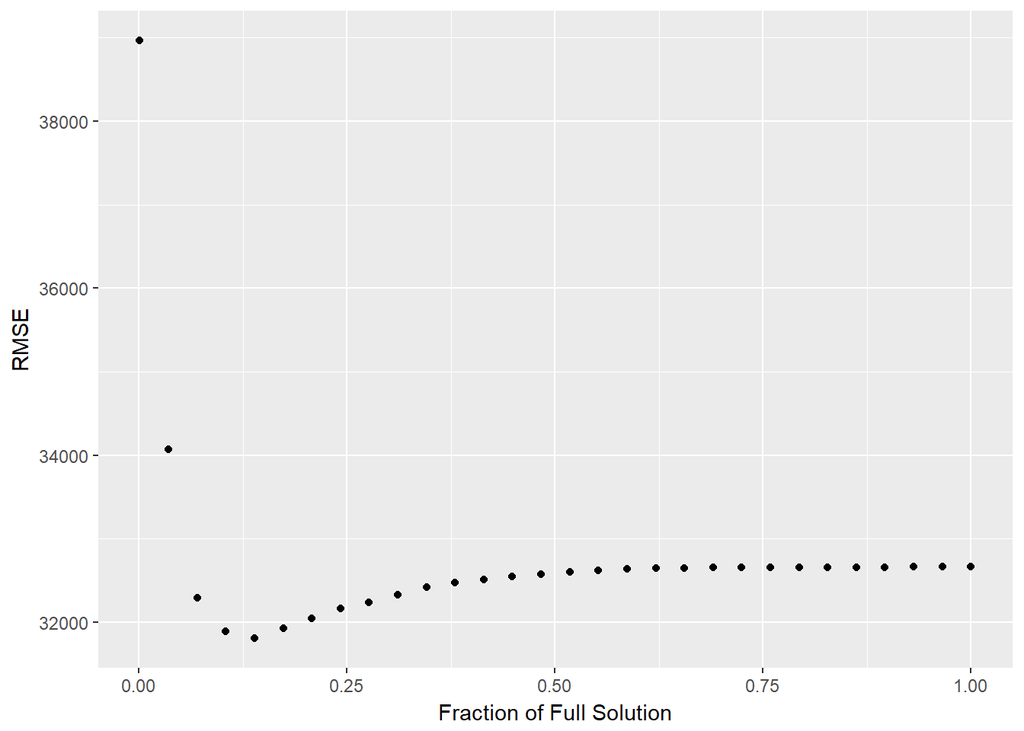

```r
ggplot(model_lasso)
```

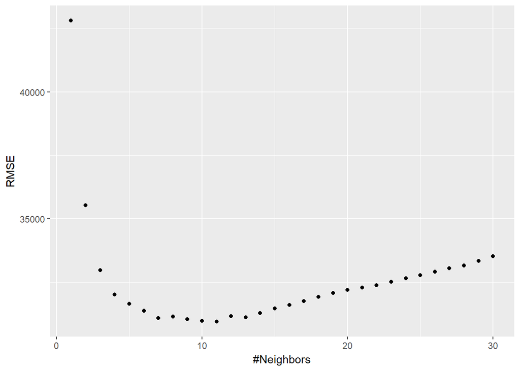

```r
ggplot(model_knn)
```

- Método Ridge: O gráfico nos mostra uma curva crescente que tem início quando o parâmetro “lambda” é 0. Mostrando que o melhor modelo seria o modelo inicial, sem nenhuma variável penalizada.
- Método Lasso: Aqui nos vemos que o parâmetro “fraction” que varia entre 0 e 1 ter um RMSE muito alto para valores do fraction próximos a 0 e depois se estabiliza quando vai chegando próximo de 0.5.
- Método KNN: Temos para este modelo que com K próximo de 0 tem um RMSE muito alto e um ponto de inflexão com k = 10. Ou seja, aumentar mais vizinhos mais que isso não ajuda mais o modelo.
3. Quais as variáveis mais importantes segundo o modelo de regressão Ridge e Lasso? Variáveis foram descartadas pelo Lasso? Quais?

As variáveis mais importantes segundo o modelo Ridge:

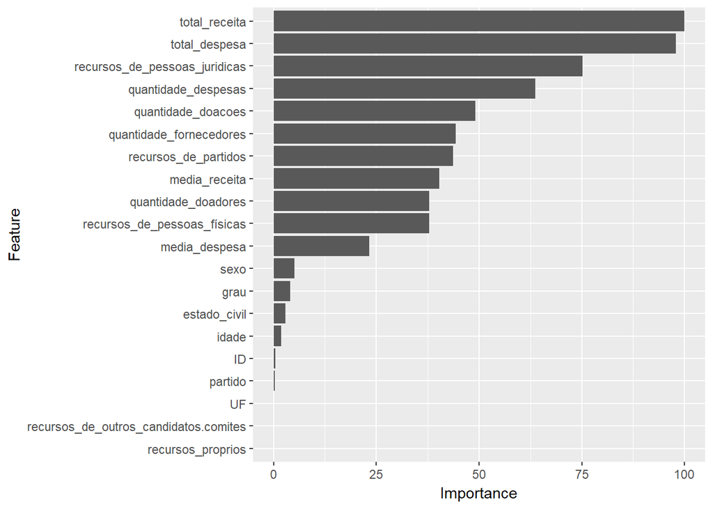

```r
#Análise Ridge
ggplot(varImp(model_ridge))
```

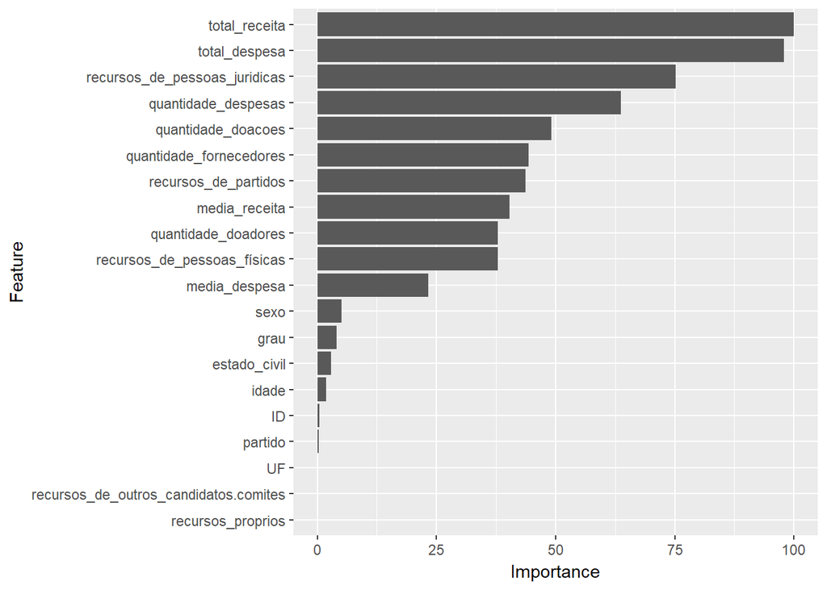

```r
#Análise Lasso
ggplot(varImp(model_lasso))
```

Basicamente, para ambos os modelos, as mesmas variáveis tem a mesma importância. Sendo que as vairáveis UF, Recursos_proprios e recursos_de_outros_candidatos.comites não tiverem importância alguma. Por não ter importância as variáveis citadas, creio que foram descartadas do modelo.

4)Re-treine o melhor modelo (usando os melhores valores de parâmetros encontrados em todos os dados, sem usar validação cruzada).

Como visto anteriormente, o melhor modelo foi o KNN com k=10. Então, vamos retreiná-lo.

```r
#grid contendo apenas o melhor valor para k (10)
bestK <- expand.grid(k = seq(10, 10, length=1))

#melhor modelo
best_model <- train(votos ~ .,
                    data = train_dadosFiltrados,
                    method = "knn",
                    tuneGrid = bestK,
                    na.action = na.omit)
```

5. Use esse último modelo treinado para prever os dados de teste disponíveis no challenge que criamos na plataforma Kaggle.

```r
submission_predict <- predict(best_model, test_dadosFiltrados)

for(i in 1:length(submission_predict)){
  submission$votos[i] = abs(submission_predict[i])
}

write.csv(submission, file = "AntonioLucioPredict.csv", row.names = FALSE)
```